# 회귀모형 I

## What is meant by a linear model?

> `uswages` dataset : The uswages data frame has 2000 rows and 10 columns. Weekly Wages for US male workers sampled from the Current Population Survey in 1988.

```r
library(faraway)
```

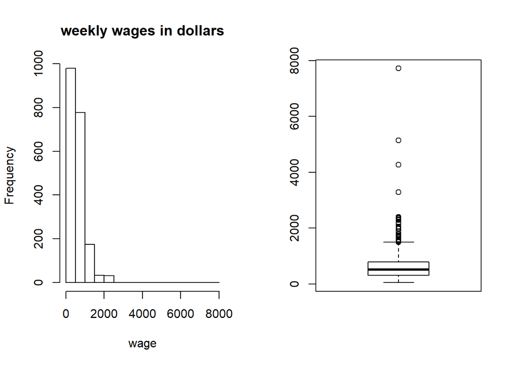

```r
attach(uswages)     # don't need to repeat declaring the use of `uswages`
par(mfrow=c(1,2))
hist(wage,main="weekly wages in dollars")
boxplot(wage)
```

```r
summary(wage)
```

```
##    Min. 1st Qu.  Median    Mean 3rd Qu.    Max.
##   50.39  308.64  522.32  608.12  783.48 7716.05
```

```r
sd(wage)
```

```
## [1] 459.8326
```

평균 주급이 약 600$이다.

Q. 이것이 2000명이 버는 돈이 모두 같다는 것을 의미하는가?

Q. 그렇지 않다면, 그 차이는 어디에 기인하는 것인가? 변동성을 무엇으로 설명할 수 있겠는가?

A. 답변을 위한 한 가지 가능한 접근은 임금에서 나타나는 변동성에 대해 어떤 설명력을 가지리라고 기대하는 또 다른 변수를 도입해 보는 것이다.

본 예제에서는 `educ` (교육기간)을 고려한다. 즉, “임금의 차이는 교육기간의 차이에서 기인한다”라고 주장하고자 하는 것이다.

```r
uswages[1:2,1:2]  # wage and educ for the first 2 observation
```

```
##         wage educ
## 6085  771.60   18
## 23701 617.28   15
```

더 오래 교육을 받은 사람이 (혹은 학력이 높은 사람이) 더 높은 임금을 받는가라고 기대할 수도 있다. 그렇다면 이것으로 충분한가? 임금이 순전히 교육기간에 의해 결정된다고 할 수 있는가?

```r
uswages[wage==92.59,1:2]  # wage and educ for observations which yield the same `wage`
```

```
##        wage educ
## 16842 92.59   11
## 3433  92.59   12
## 18669 92.59    8
## 8258  92.59   12
## 27780 92.59   12
## 25653 92.59   11
## 11135 92.59   12
```

```r
uswages[educ==5,1:2]  # wage and educ for observations which yield the same `educ`
```

```
##         wage educ
## 2698  949.67    5
## 5405  284.90    5
## 25981 804.84    5
## 25701 142.45    5
## 21219 213.68    5
## 26991 493.83    5
## 19203 189.93    5
```

교육기간 외에도 임금을 결정하는 또 다른 무엇인가가 있다고 볼 수 있다. 즉, 노동자들의 임금에서 나타나는 변동성을 교육기간에 의해 결정되는 부분과 그렇지 않은 부분 (나머지)로 나누어 생각할 수 있다.

요약하자면, 다음과 같이 표현할 수 있다.

$$\mbox{wage} = \mbox{part explained by educ} + \mbox{part not explained by educ}$$
$$\mbox{variation of wage} = \mbox{variation explained by educ} + \mbox{variation not explained by educ}$$

좀 더 수학적인 표현으로는

$$wage = f(educ) + remainder$$

통계학에서는 $remainder$ 부분을 보통 `error`로 지칭하고 $\epsilon$로 표현한다.

$$wage = f(educ) + \epsilon$$

예컨데, 5년의 교육기간을 가진 사람들의 평균임금이 439.9$일 때, 각 관측치값에 대해서 `educ`로는 설명되지 않는 부분이 있을 것이다.

```r
e1 = uswages[educ==5,1:2]
(m1 = lapply(e1,mean))  # average wage
```

```
## $wage
## [1] 439.9
##
## $educ
## [1] 5
```

```r
e1$wage-m1$wage  # wage - average wage for this group
```

```
## [1]  509.77 -155.00  364.94 -297.45 -226.22   53.93 -249.97
```

$f$는 `wage`가 `educ`에 의해 설명되는 방식 혹은 패턴을 나타낸다. 수학적으로는 함수로 보면 된다.

$f$의 형태에 대한 선택은 여러가지 상황에 의존하는데 보통 연구자의 관심, 믿음 혹은 관측된 데이터의 특성등에 의해 결정된다. 일반적으로 $f$의 형태를 정확히 알지 못하는 경우가 대부분이며 본격적인 분석(혹은 추정)에 앞서서 결정해야 할 필요가 있다. 때로는 오차항 또한 좀 더 일반적인 형태로 모형에 포함되기도 한다. 가장 간단하게 고려해 볼 수 있는 경우는 $f$를 선형함수로 두고 오차항은 합(additive)의 형태로 모형에 포함시키는 것이다.

$$wage = \beta_0+\beta_1 \cdot educ + \epsilon.$$

이와 같은 모형을 일컬어 단순선형회귀모형이라 한다. `wage`를 반응변수(response), `educ`를 설명변수 혹은 예측변수 (explanatory variable or predictor). $\beta_0$는 절편항으로 반응변수의 전반적인 수준(크기)를 보여주고, $\beta_1$은 기울기로 예측변수의 반응변수에 대한 영향력을 표현하게 된다. 이 둘은 알지 못하는(unknown) 상태이며 따라서 모형에서 추정이 필요한 상수 (parameter) 이다. 회귀모형에서 변수의 영향력을 나타낸다는 의미로 회귀계수라고도 부른다. 모수의 추정은 현재 주어진 데이터로부터 어떤 방식으로든 이루어지게 된다. 단순선형회귀모형에서는 반응변수와 예측변수의 관계를 직접적으로 반영해주는 $\beta_1$이 $\beta_0$보다 보통 더 중요하게 간주된다.

추정 단계에서는 그렇지 않지만, 이후에 추론을 위해서는 오차항에 대한 가정이 필요한 경우가 많다. 이에 대해서는 나중에 다룰 예정이다.

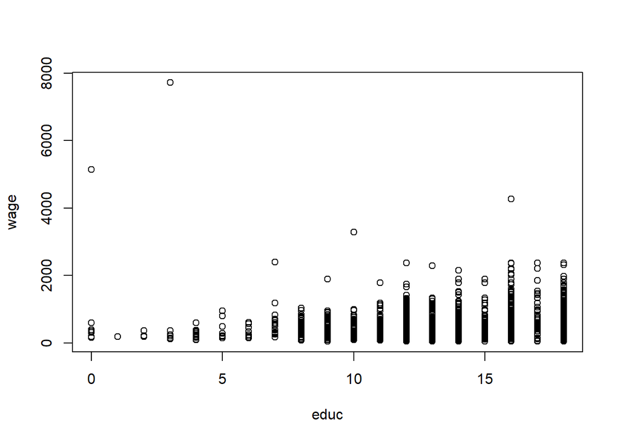

```r
plot(wage ~ educ)
```

위 그림으로부터 `educ`의 증가에 따라 `wage` 가 함께 증가하는 패턴이 있음을 알 수 있다. 이 패턴이 선형이라 볼 수 있는가? 선형회귀모형으로 변수들 사이의 관계를 충분히 잡아낼 수 있는가?

때로는 심각하게 질문해야 할 수 있지만, 때로는 너무 고민하지 않고 일단 실행해 보는 것이 필요하다. 만약, 모형에 대한 추정 및 추론결과가 충분히 의미있다면 유용할 수 있다. 통계적모형화는 현실을 정확히 알아내는 것보다는 현실에 대한 좋은 근사를 찾기 위한 경우가 많다.

## 추정

추정을 위한 접근법은 매우 다양하게 존재한다. 회귀모형에서 모수를 추정하기 위한 가장 일반적인 방법 중 하나는 최소제곱법(least-squares method)이다. 다음과 같이 $n$개의 순서쌍으로 관측치를 얻었다고 가정하자.

$$(x_i,y_i) ,~i=1,2,\ldots,n.$$

단순선형회귀모형은 다음과 같이 표현될 수 있다.

$$y_i = \beta_0 + \beta_1 x_i + \epsilon_i.$$

최소제곱추정법이란 오차제곱합을 가장 작게 만드는 선형함수를 찾는 것이다. 즉, 다음과 같은 오차제곱합을 최소화하는 $\beta_0$, $\beta_1$을 찾는 것이다.

$$\sum_{i=1}^n \epsilon_i^2 = \sum_{i=1}^n (Y_i - \beta_0 - \beta_1 X_i)^2$$

위 문제는 결국 2개의 선형방정식을 연립하여 푸는 것으로 귀결된다. 추정량은 다음과 같이 주어진다.

$$\hat\beta_1 = \frac{\sum_{i=1}^n (x_i - \bar x)(y_i - \bar y)}{\sum_{i=1}^n (x_i - \bar x)^2},~\hat\beta_0 = \bar y - \hat\beta_1 \bar x.$$

추정치는 통계소프트웨어 등을 통해 쉽게 계산된다. `R`에서는 `lm` 함수를 이용하는 것이 보통이다.

```r
(fit1=lm(wage~educ))
```

```
##
## Call:
## lm(formula = wage ~ educ)
##
## Coefficients:
## (Intercept)         educ
##      109.75        38.01
```

```r
ls(fit1)
```

```
##  [1] "assign"        "call"          "coefficients"  "df.residual"
##  [5] "effects"       "fitted.values" "model"         "qr"
##  [9] "rank"          "residuals"     "terms"         "xlevels"
```

예측변수의 관측치로부터 추정된 모수(추정치)를 모형에 넣어 얻어진 반응변수의 값을 fitted value라 한다.

$$\hat y_i = \hat\beta_0 + \hat\beta_1 x_i$$

만약, 미래의 새로운 관측치가 있고 예측변수의 값이$x_0$라면, 모형으로부터 예측된 반응변수의 값 (predicted value)은$\hat y_i|_{x_0} = \beta_0 + \beta_1 x_0$이 될 것이다.

반응변수의 관측치와 fitted value 사이의 차이를 잔차(residual)라 한다.

$$e_ i = y_i - \hat y_i.$$

잔차는 오차의 realized version으로 생각할 수도 있다.

```r
head(fit1$fitted.values)
```

```
##        1        2        3        4        5        6
## 793.9543 679.9209 717.9320 565.8875 641.9098 565.8875
```

```r
head(fit1$residuals)
```

```
##          1          2          3          4          5          6
##  -22.35431  -62.64090  239.89796   51.39251  260.27023 -266.73749
```

위에서 언급했던 반응변수의 분해는 다음과 같이 표현하는 것도 가능하다.

$$\mbox{Data} = \mbox{Systematic structure} + \mbox{random variation}$$

“systematic structure” 는 “model part”로 부르기도 하고 “random variation” 은 “stochastic or error part”로 부르기도 한다. 전자는 보통 deterministic 즉, 확률분포가 없는 fixed term으로 간주되지만 후자는 항상 randomness가 존재하는 확률변수이다. 특별한 경우를 제외하고는 오차항은 그 분포가 대칭인 것으로 가정하며 (혹은 평균이 0) 분산이 존재하는 것으로 간주한다. 오차항의 분산($\sigma^2 = E(\epsilon^2)$) 또한 관심대상이 되는 경우도 있다.

단순선형회귀모형에서는 오차항의 분산에 대한 sample version (estimator)로 MSE가 주로 쓰인다.

$$MSE = RSS/(n-2) = \frac{\sum_{i=1}^n e_i^2}{n-2}.$$

```r
mean(fit1$residuals)  # exactly 0?
```

```
## [1] 5.784567e-15
```

```r
sum(fit1$residuals^2)/(length(wage)-2)  # MSE
```

```
## [1] 198505.3
```

아래는 적합된(혹은 추정된) 회귀직선이다. 전반적인 추세를 나타낸다고 볼 수 있다.

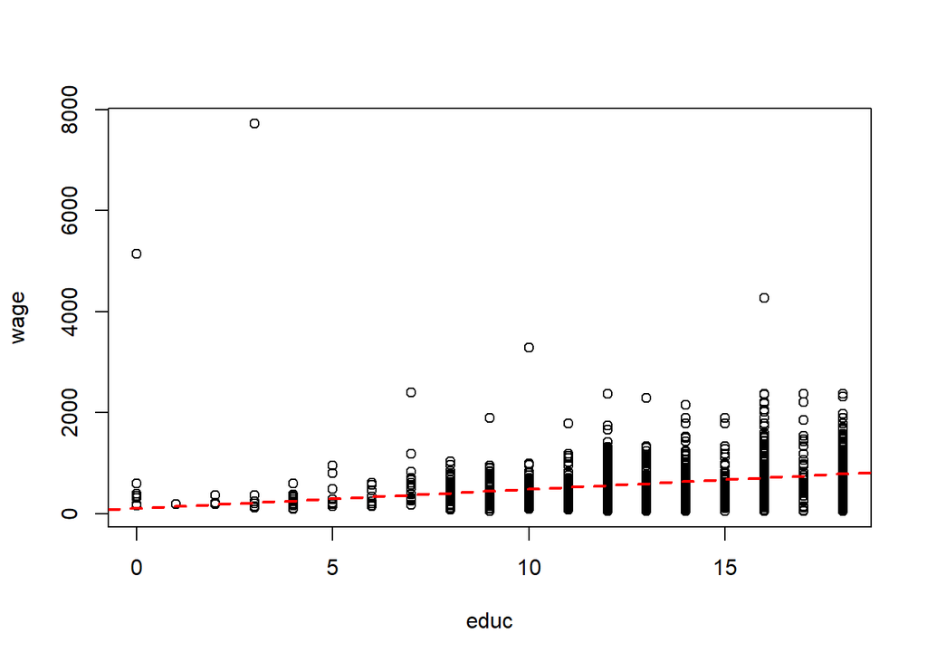

```r
plot(wage~educ)
abline(fit1,col=2,lwd=2,lty=2)
```

## 변동의 분해

Q. Is the point $(\bar x , \bar y)$ on the fitted regression function?

A. Yes

Note that for $i$th observation.

$$y_i - \bar y = (y_i - \hat y_i) + (\hat y_i - \bar y).$$

Q. 각 부분은 무엇을 의미하는가?

위 분해된 결과를 모든 관측치에 대해서 요약(합)하면,

$$\sum_{i=1}^n (y_i - \bar y)^2 = \sum_{i=1}^n (\hat y_i - \bar y)^2 + \sum_{i=1}^n (y_i - \hat y_i)^2 .$$

$$SST = SSR + SSE(RSS).$$

SST : total sum of squares, SSR : regression sum of squares, SSE : sum of squared error

$$\mbox{total variation} = \mbox{variation explained by predictor} + \mbox{variation not explained by predictor}$$

```r
(SST=sum((wage-mean(wage))^2))
```

```
## [1] 422680648
```

```r
(SSR=sum((mean(wage)-fit1$fitted.values)^2))
```

```
## [1] 26066994
```

```r
(RSS=sum(fit1$residuals^2))
```

```
## [1] 396613654
```

```r
SST-(SSR+RSS)
```

```
## [1] 0
```

SSE에 비해 SSR이 크다는 것은 적합된 모형이 좀 더 설명력이 있다는 뜻으로 볼 수 있다. 이에 대한 측도로 결정계수(coefficient of determination) $R^2$ 를 정의한다.

$$R^2 = SSR/SST$$

```r
(R2 = SSR/SST)
```

```
## [1] 0.06167066
```

Note that indeed $R^2$ coincides the squared correlation coefficient.

```r
cor(wage,educ)^2
```

```
## [1] 0.06167066
```

```r
summary(fit1)
```

```
##
## Call:
## lm(formula = wage ~ educ)
##
## Residuals:
##    Min     1Q Median     3Q    Max
## -743.6 -269.5  -67.7  173.0 7492.3
##
## Coefficients:
##             Estimate Std. Error t value Pr(>|t|)
## (Intercept)  109.754     44.616    2.46    0.014 *
## educ          38.011      3.317   11.46   <2e-16 ***
## ---
## Signif. codes:  0 '***' 0.001 '**' 0.01 '*' 0.05 '.' 0.1 ' ' 1
##
## Residual standard error: 445.5 on 1998 degrees of freedom
## Multiple R-squared:  0.06167,    Adjusted R-squared:  0.0612
## F-statistic: 131.3 on 1 and 1998 DF,  p-value: < 2.2e-16
```

```r
aov(fit1)      # ANOVA table
```

```
## Call:
##    aov(formula = fit1)
##
## Terms:
##                      educ Residuals
## Sum of Squares   26066994 396613654
## Deg. of Freedom         1      1998
##
## Residual standard error: 445.5394
## Estimated effects may be unbalanced
```